# Appendix C

Allison Binley

January 5, 2022

Detailed example of IHM and SHM calculations for Magnolia Warbler in the breeding season.

SHM

Limit to base regression models for stixels within the specified temporal extent. For Magnolia Warbler, this is stixels that model occurrence between June 14 and August 3. PIs will only be extracted for models that fall within these dates. Occurrence estimates for the breeding period for Magnolia Warbler are based on an ensemble of 9712 base models, therefore we have 9712 measures of predictor importance for each land cover class for this species.

```r
library(tidyverse)
bird_data <- read.csv("data/bird_data_v4.csv")
load("D:/Allison/Github_Projects/Ch-2/Ch-2/data_outputs/rpis_breeding_2019.RData")

magwar <- rpis_id_breeding %>%
  filter(species_code == "magwar")

n_distinct(magwar$stixel_id)
```

```
## [1] 9712
```

```r
library(sf)
```

```r
load("appendix_plots/appC1.RData")

#Figure S1
#plot(st_geometry(stixels2), col = "#1F968BFF")
#plot(ne_land, add=T)
#plot(ne_country_lines, add=T)
```

Each stixel represents a spatiotemporal pixel in which a regression model is fitted to model Magnolia Warbler occurrence. For each model, a predictor importance value can be calculated for each predictor in the model, measuring the relative decrease in model fit if that predictor were to be removed, keeping all other predictors constant (or averaging across them?). Stixels may overlap in time and space.

The land cover predictors that remained were: "Tidal Mudflats", "Barren", "Permanent Snow and Ice", "Evergreen Needleleaf Forests", "Evergreen Broadleaf Forests", "Deciduous Needleleaf Forests", "Deciduous Broadleaf Forests", "Mixed Broadleaf/Needleleaf Forests", "Mixed Broadleaf Evergreen/Deciduous Forests", "Open Forests", "Sparse Forests", "Unclassified", "Dense Herbaceous", "Sparse Herbaceous", "Dense Shrublands", "Shrubland/Grassland Mosaics", "Sparse Shrublands", "Forest/Cropland Mosaics", "Natural Herbaceous/Croplands Mosaics", "Herbaceous Croplands", "Woody Wetlands", "Herbaceous Wetlands", and "Tundra". The landscape metric used for all land-cover classes was proportion of landscape (PLAND).

Predictor importance values for each land-cover class in each stixel were rescaled to calculate a relative predictor importance for each, where the sum of all predictor importance values for a given stixel added to 1 (Figure S2).

[figure not shown]

[figure not shown]

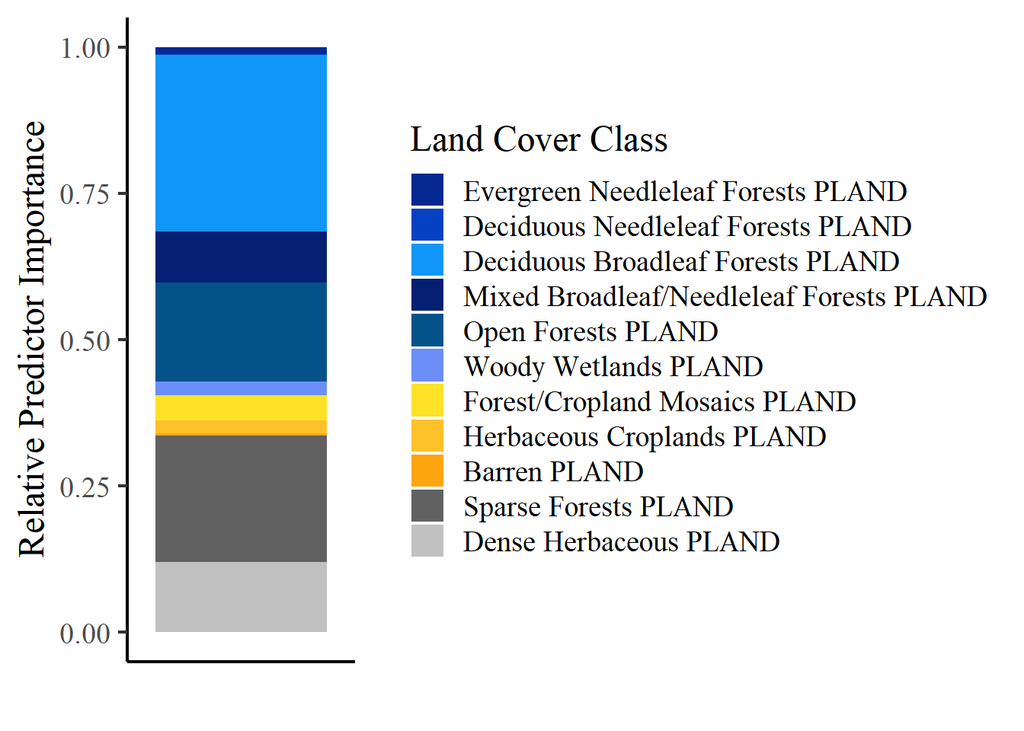